# Risk Factor Analysis

## Outcome Variable

**Outcome Variable:** y_rate_haz

## Predictor Variables

**Intervention Variable:** cleanck

**Adjustment Set:**

- arm
- sex
- W_mage
- meducyrs
- feducyrs
- hhwealth_quart
- W_nrooms
- W_nhh
- W_nchldlt5
- W_parity
- trth2o
- impfloor
- delta_meducyrs
- delta_feducyrs
- delta_hhwealth_quart
- delta_W_nrooms
- delta_W_nhh
- delta_W_nchldlt5
- delta_W_parity
- delta_trth2o
- delta_impfloor

## Stratifying Variables

The analysis was stratified on these variable(s):

- agecat
- studyid
- country

## Data Summary

| agecat | studyid | country | cleanck | n_cell | n |
| --- | --- | --- | --- | --- | --- |
| 0-3 months | ki0047075b-MAL-ED | PERU | 0 | 0 | 1 |
| 0-3 months | ki0047075b-MAL-ED | PERU | 1 | 1 | 1 |
| 0-3 months | ki0047075b-MAL-ED | SOUTH AFRICA | 0 | 1 | 2 |
| 0-3 months | ki0047075b-MAL-ED | SOUTH AFRICA | 1 | 1 | 2 |
| 0-3 months | ki1000108-CMC-V-BCS-2002 | INDIA | 0 | 48 | 87 |
| 0-3 months | ki1000108-CMC-V-BCS-2002 | INDIA | 1 | 39 | 87 |
| 0-3 months | ki1000108-IRC | INDIA | 0 | 157 | 369 |
| 0-3 months | ki1000108-IRC | INDIA | 1 | 212 | 369 |
| 0-3 months | ki1017093b-PROVIDE | BANGLADESH | 0 | 109 | 634 |
| 0-3 months | ki1017093b-PROVIDE | BANGLADESH | 1 | 525 | 634 |
| 0-3 months | ki1017093c-NIH-Crypto | BANGLADESH | 0 | 213 | 546 |
| 0-3 months | ki1017093c-NIH-Crypto | BANGLADESH | 1 | 333 | 546 |
| 3-6 months | ki0047075b-MAL-ED | SOUTH AFRICA | 0 | 0 | 1 |
| 3-6 months | ki0047075b-MAL-ED | SOUTH AFRICA | 1 | 1 | 1 |
| 3-6 months | ki1000108-CMC-V-BCS-2002 | INDIA | 0 | 174 | 307 |
| 3-6 months | ki1000108-CMC-V-BCS-2002 | INDIA | 1 | 133 | 307 |
| 3-6 months | ki1000108-IRC | INDIA | 0 | 166 | 390 |
| 3-6 months | ki1000108-IRC | INDIA | 1 | 224 | 390 |
| 3-6 months | ki1017093b-PROVIDE | BANGLADESH | 0 | 99 | 574 |
| 3-6 months | ki1017093b-PROVIDE | BANGLADESH | 1 | 475 | 574 |
| 3-6 months | ki1017093c-NIH-Crypto | BANGLADESH | 0 | 212 | 527 |
| 3-6 months | ki1017093c-NIH-Crypto | BANGLADESH | 1 | 315 | 527 |
| 3-6 months | ki1113344-GMS-Nepal | NEPAL | 0 | 840 | 852 |
| 3-6 months | ki1113344-GMS-Nepal | NEPAL | 1 | 12 | 852 |
| 6-12 months | ki0047075b-MAL-ED | SOUTH AFRICA | 0 | 0 | 1 |
| 6-12 months | ki0047075b-MAL-ED | SOUTH AFRICA | 1 | 1 | 1 |
| 6-12 months | ki1000108-CMC-V-BCS-2002 | INDIA | 0 | 185 | 323 |
| 6-12 months | ki1000108-CMC-V-BCS-2002 | INDIA | 1 | 138 | 323 |
| 6-12 months | ki1000108-IRC | INDIA | 0 | 164 | 391 |
| 6-12 months | ki1000108-IRC | INDIA | 1 | 227 | 391 |
| 6-12 months | ki1017093b-PROVIDE | BANGLADESH | 0 | 96 | 545 |
| 6-12 months | ki1017093b-PROVIDE | BANGLADESH | 1 | 449 | 545 |
| 6-12 months | ki1017093c-NIH-Crypto | BANGLADESH | 0 | 214 | 516 |
| 6-12 months | ki1017093c-NIH-Crypto | BANGLADESH | 1 | 302 | 516 |
| 6-12 months | ki1113344-GMS-Nepal | NEPAL | 0 | 840 | 856 |
| 6-12 months | ki1113344-GMS-Nepal | NEPAL | 1 | 16 | 856 |
| 12-24 months | ki0047075b-MAL-ED | SOUTH AFRICA | 0 | 0 | 1 |
| 12-24 months | ki0047075b-MAL-ED | SOUTH AFRICA | 1 | 1 | 1 |
| 12-24 months | ki1000108-CMC-V-BCS-2002 | INDIA | 0 | 191 | 324 |
| 12-24 months | ki1000108-CMC-V-BCS-2002 | INDIA | 1 | 133 | 324 |
| 12-24 months | ki1000108-IRC | INDIA | 0 | 163 | 387 |
| 12-24 months | ki1000108-IRC | INDIA | 1 | 224 | 387 |
| 12-24 months | ki1017093b-PROVIDE | BANGLADESH | 0 | 80 | 458 |
| 12-24 months | ki1017093b-PROVIDE | BANGLADESH | 1 | 378 | 458 |
| 12-24 months | ki1017093c-NIH-Crypto | BANGLADESH | 0 | 211 | 396 |
| 12-24 months | ki1017093c-NIH-Crypto | BANGLADESH | 1 | 185 | 396 |
| 12-24 months | ki1113344-GMS-Nepal | NEPAL | 0 | 646 | 656 |
| 12-24 months | ki1113344-GMS-Nepal | NEPAL | 1 | 10 | 656 |

The following strata were considered:

- agecat: 0-3 months, studyid: ki0047075b-MAL-ED, country: PERU
- agecat: 0-3 months, studyid: ki0047075b-MAL-ED, country: SOUTH AFRICA
- agecat: 0-3 months, studyid: ki1000108-CMC-V-BCS-2002, country: INDIA
- agecat: 0-3 months, studyid: ki1000108-IRC, country: INDIA
- agecat: 0-3 months, studyid: ki1017093b-PROVIDE, country: BANGLADESH
- agecat: 0-3 months, studyid: ki1017093c-NIH-Crypto, country: BANGLADESH
- agecat: 12-24 months, studyid: ki0047075b-MAL-ED, country: SOUTH AFRICA
- agecat: 12-24 months, studyid: ki1000108-CMC-V-BCS-2002, country: INDIA
- agecat: 12-24 months, studyid: ki1000108-IRC, country: INDIA
- agecat: 12-24 months, studyid: ki1017093b-PROVIDE, country: BANGLADESH
- agecat: 12-24 months, studyid: ki1017093c-NIH-Crypto, country: BANGLADESH
- agecat: 12-24 months, studyid: ki1113344-GMS-Nepal, country: NEPAL
- agecat: 3-6 months, studyid: ki0047075b-MAL-ED, country: SOUTH AFRICA
- agecat: 3-6 months, studyid: ki1000108-CMC-V-BCS-2002, country: INDIA
- agecat: 3-6 months, studyid: ki1000108-IRC, country: INDIA
- agecat: 3-6 months, studyid: ki1017093b-PROVIDE, country: BANGLADESH
- agecat: 3-6 months, studyid: ki1017093c-NIH-Crypto, country: BANGLADESH
- agecat: 3-6 months, studyid: ki1113344-GMS-Nepal, country: NEPAL
- agecat: 6-12 months, studyid: ki0047075b-MAL-ED, country: SOUTH AFRICA
- agecat: 6-12 months, studyid: ki1000108-CMC-V-BCS-2002, country: INDIA
- agecat: 6-12 months, studyid: ki1000108-IRC, country: INDIA
- agecat: 6-12 months, studyid: ki1017093b-PROVIDE, country: BANGLADESH
- agecat: 6-12 months, studyid: ki1017093c-NIH-Crypto, country: BANGLADESH
- agecat: 6-12 months, studyid: ki1113344-GMS-Nepal, country: NEPAL

### Dropped Strata

Some strata were dropped due to rare outcomes:

- agecat: 0-3 months, studyid: ki0047075b-MAL-ED, country: PERU
- agecat: 0-3 months, studyid: ki0047075b-MAL-ED, country: SOUTH AFRICA
- agecat: 3-6 months, studyid: ki0047075b-MAL-ED, country: SOUTH AFRICA
- agecat: 6-12 months, studyid: ki0047075b-MAL-ED, country: SOUTH AFRICA
- agecat: 12-24 months, studyid: ki0047075b-MAL-ED, country: SOUTH AFRICA

## Methods Detail

We’re interested in the causal parameters $E[Y_a]$ for all values of $a \in \mathcal{A}$. These parameters represent the mean outcome if, possibly contrary to fact, we intervened to set all units to have $A=a$. Under the randomization and positivity assumptions, these are identified by the statistical parameters $\psi_a=E_W[E_{Y|A,W}(Y|A=a,W)]$. In addition, we’re interested in the mean of $Y$, $E[Y]$ under no intervention (the observed mean). We will estimate these parameters by using SuperLearner to fit the relevant likelihood factors – $E_{Y|A,W}(Y|A=a,W)$ and $p(A=a|W)$, and then updating our likelihood fit using a joint TMLE.

For unadjusted analyses ($W=\{\}$), initial likelihoods were estimated using Lrnr_glm to estimate the simple $E(Y|A)$ and Lrnr_mean to estimate $p(A)$. For adjusted analyses, a small library containing Lrnr_glmnet, Lrnr_xgboost, and Lrnr_mean was used.

Having estimated these parameters, we will then use the delta method to estimate relative risks and attributable risks relative to a prespecified baseline level of $A$.

# Results Detail

## Results Plots

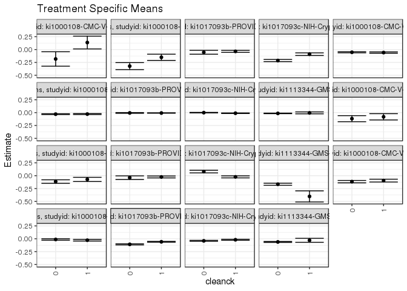

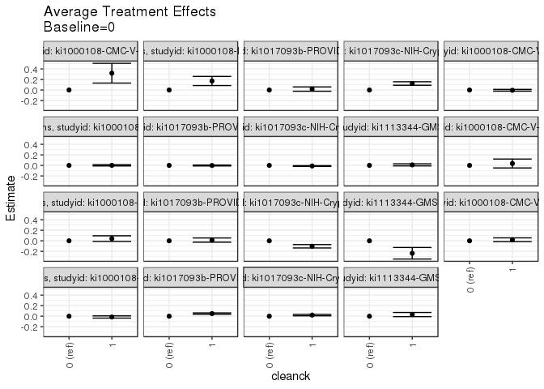

## Results Table

### Parameter: TSM

| agecat | studyid | country | intervention_level | baseline_level | estimate | ci_lower | ci_upper |
| --- | --- | --- | --- | --- | --- | --- | --- |
| 0-3 months | ki1000108-CMC-V-BCS-2002 | INDIA | 0 | NA | -0.1831478 | -0.3235052 | -0.0427904 |
| 0-3 months | ki1000108-CMC-V-BCS-2002 | INDIA | 1 | NA | 0.1362768 | 0.0118262 | 0.2607274 |
| 0-3 months | ki1000108-IRC | INDIA | 0 | NA | -0.3220998 | -0.3899297 | -0.2542699 |
| 0-3 months | ki1000108-IRC | INDIA | 1 | NA | -0.1508075 | -0.2113804 | -0.0902345 |
| 0-3 months | ki1017093b-PROVIDE | BANGLADESH | 0 | NA | -0.0531045 | -0.0904391 | -0.0157699 |
| 0-3 months | ki1017093b-PROVIDE | BANGLADESH | 1 | NA | -0.0353943 | -0.0546949 | -0.0160937 |
| 0-3 months | ki1017093c-NIH-Crypto | BANGLADESH | 0 | NA | -0.2132516 | -0.2346038 | -0.1918995 |
| 0-3 months | ki1017093c-NIH-Crypto | BANGLADESH | 1 | NA | -0.0898937 | -0.1148048 | -0.0649826 |
| 3-6 months | ki1000108-CMC-V-BCS-2002 | INDIA | 0 | NA | -0.1178397 | -0.1765359 | -0.0591436 |
| 3-6 months | ki1000108-CMC-V-BCS-2002 | INDIA | 1 | NA | -0.0816304 | -0.1431369 | -0.0201238 |
| 3-6 months | ki1000108-IRC | INDIA | 0 | NA | -0.1140610 | -0.1482947 | -0.0798273 |
| 3-6 months | ki1000108-IRC | INDIA | 1 | NA | -0.0722137 | -0.1127929 | -0.0316345 |
| 3-6 months | ki1017093b-PROVIDE | BANGLADESH | 0 | NA | -0.0388138 | -0.0739086 | -0.0037189 |
| 3-6 months | ki1017093b-PROVIDE | BANGLADESH | 1 | NA | -0.0248310 | -0.0432819 | -0.0063801 |
| 3-6 months | ki1017093c-NIH-Crypto | BANGLADESH | 0 | NA | 0.0802723 | 0.0547011 | 0.1058435 |
| 3-6 months | ki1017093c-NIH-Crypto | BANGLADESH | 1 | NA | -0.0230703 | -0.0429829 | -0.0031577 |
| 3-6 months | ki1113344-GMS-Nepal | NEPAL | 0 | NA | -0.1660684 | -0.1858426 | -0.1462942 |
| 3-6 months | ki1113344-GMS-Nepal | NEPAL | 1 | NA | -0.4024319 | -0.5105302 | -0.2943336 |
| 6-12 months | ki1000108-CMC-V-BCS-2002 | INDIA | 0 | NA | -0.1155469 | -0.1388497 | -0.0922440 |
| 6-12 months | ki1000108-CMC-V-BCS-2002 | INDIA | 1 | NA | -0.0953728 | -0.1228643 | -0.0678814 |
| 6-12 months | ki1000108-IRC | INDIA | 0 | NA | -0.0135645 | -0.0277395 | 0.0006104 |
| 6-12 months | ki1000108-IRC | INDIA | 1 | NA | -0.0281708 | -0.0442022 | -0.0121394 |
| 6-12 months | ki1017093b-PROVIDE | BANGLADESH | 0 | NA | -0.1085987 | -0.1196266 | -0.0975708 |
| 6-12 months | ki1017093b-PROVIDE | BANGLADESH | 1 | NA | -0.0589020 | -0.0663804 | -0.0514236 |
| 6-12 months | ki1017093c-NIH-Crypto | BANGLADESH | 0 | NA | -0.0405506 | -0.0503724 | -0.0307288 |
| 6-12 months | ki1017093c-NIH-Crypto | BANGLADESH | 1 | NA | -0.0194102 | -0.0293422 | -0.0094782 |
| 6-12 months | ki1113344-GMS-Nepal | NEPAL | 0 | NA | -0.0613893 | -0.0702746 | -0.0525039 |
| 6-12 months | ki1113344-GMS-Nepal | NEPAL | 1 | NA | -0.0299260 | -0.0683814 | 0.0085294 |
| 12-24 months | ki1000108-CMC-V-BCS-2002 | INDIA | 0 | NA | -0.0534684 | -0.0640882 | -0.0428485 |
| 12-24 months | ki1000108-CMC-V-BCS-2002 | INDIA | 1 | NA | -0.0586543 | -0.0716311 | -0.0456776 |
| 12-24 months | ki1000108-IRC | INDIA | 0 | NA | -0.0300170 | -0.0374175 | -0.0226166 |
| 12-24 months | ki1000108-IRC | INDIA | 1 | NA | -0.0286814 | -0.0380054 | -0.0193574 |
| 12-24 months | ki1017093b-PROVIDE | BANGLADESH | 0 | NA | -0.0061408 | -0.0138469 | 0.0015652 |
| 12-24 months | ki1017093b-PROVIDE | BANGLADESH | 1 | NA | -0.0077830 | -0.0120550 | -0.0035111 |
| 12-24 months | ki1017093c-NIH-Crypto | BANGLADESH | 0 | NA | -0.0006306 | -0.0055495 | 0.0042882 |
| 12-24 months | ki1017093c-NIH-Crypto | BANGLADESH | 1 | NA | -0.0117910 | -0.0169069 | -0.0066751 |
| 12-24 months | ki1113344-GMS-Nepal | NEPAL | 0 | NA | -0.0149623 | -0.0204077 | -0.0095170 |
| 12-24 months | ki1113344-GMS-Nepal | NEPAL | 1 | NA | -0.0050037 | -0.0235690 | 0.0135617 |

### Parameter: E(Y)

| agecat | studyid | country | intervention_level | baseline_level | estimate | ci_lower | ci_upper |
| --- | --- | --- | --- | --- | --- | --- | --- |
| 0-3 months | ki1000108-CMC-V-BCS-2002 | INDIA | NA | NA | -0.0732952 | -0.1806423 | 0.0340519 |
| 0-3 months | ki1000108-IRC | INDIA | NA | NA | -0.2555832 | -0.3120360 | -0.1991304 |
| 0-3 months | ki1017093b-PROVIDE | BANGLADESH | NA | NA | -0.0413143 | -0.0594662 | -0.0231624 |
| 0-3 months | ki1017093c-NIH-Crypto | BANGLADESH | NA | NA | -0.1140109 | -0.1341708 | -0.0938510 |
| 3-6 months | ki1000108-CMC-V-BCS-2002 | INDIA | NA | NA | -0.0979615 | -0.1455947 | -0.0503283 |
| 3-6 months | ki1000108-IRC | INDIA | NA | NA | -0.0517747 | -0.0822588 | -0.0212906 |
| 3-6 months | ki1017093b-PROVIDE | BANGLADESH | NA | NA | -0.0272428 | -0.0436954 | -0.0107902 |
| 3-6 months | ki1017093c-NIH-Crypto | BANGLADESH | NA | NA | 0.0302642 | 0.0105575 | 0.0499710 |
| 3-6 months | ki1113344-GMS-Nepal | NEPAL | NA | NA | -0.1695159 | -0.1892757 | -0.1497561 |
| 6-12 months | ki1000108-CMC-V-BCS-2002 | INDIA | NA | NA | -0.0993395 | -0.1199006 | -0.0787784 |
| 6-12 months | ki1000108-IRC | INDIA | NA | NA | -0.0274878 | -0.0401239 | -0.0148518 |
| 6-12 months | ki1017093b-PROVIDE | BANGLADESH | NA | NA | -0.0626151 | -0.0695574 | -0.0556729 |
| 6-12 months | ki1017093c-NIH-Crypto | BANGLADESH | NA | NA | -0.0282840 | -0.0367845 | -0.0197836 |
| 6-12 months | ki1113344-GMS-Nepal | NEPAL | NA | NA | -0.0608825 | -0.0696769 | -0.0520880 |
| 12-24 months | ki1000108-CMC-V-BCS-2002 | INDIA | NA | NA | -0.0455184 | -0.0556929 | -0.0353439 |
| 12-24 months | ki1000108-IRC | INDIA | NA | NA | -0.0313101 | -0.0385075 | -0.0241127 |
| 12-24 months | ki1017093b-PROVIDE | BANGLADESH | NA | NA | -0.0081718 | -0.0120131 | -0.0043304 |
| 12-24 months | ki1017093c-NIH-Crypto | BANGLADESH | NA | NA | -0.0030765 | -0.0074275 | 0.0012744 |
| 12-24 months | ki1113344-GMS-Nepal | NEPAL | NA | NA | -0.0148291 | -0.0202110 | -0.0094472 |

### Parameter: ATE

| agecat | studyid | country | intervention_level | baseline_level | estimate | ci_lower | ci_upper |
| --- | --- | --- | --- | --- | --- | --- | --- |
| 0-3 months | ki1000108-CMC-V-BCS-2002 | INDIA | 0 | 0 | 0.0000000 | 0.0000000 | 0.0000000 |
| 0-3 months | ki1000108-CMC-V-BCS-2002 | INDIA | 1 | 0 | 0.3194246 | 0.1316083 | 0.5072409 |
| 0-3 months | ki1000108-IRC | INDIA | 0 | 0 | 0.0000000 | 0.0000000 | 0.0000000 |
| 0-3 months | ki1000108-IRC | INDIA | 1 | 0 | 0.1712923 | 0.0847486 | 0.2578360 |
| 0-3 months | ki1017093b-PROVIDE | BANGLADESH | 0 | 0 | 0.0000000 | 0.0000000 | 0.0000000 |
| 0-3 months | ki1017093b-PROVIDE | BANGLADESH | 1 | 0 | 0.0177102 | -0.0231107 | 0.0585311 |
| 0-3 months | ki1017093c-NIH-Crypto | BANGLADESH | 0 | 0 | 0.0000000 | 0.0000000 | 0.0000000 |
| 0-3 months | ki1017093c-NIH-Crypto | BANGLADESH | 1 | 0 | 0.1233579 | 0.0901529 | 0.1565630 |
| 3-6 months | ki1000108-CMC-V-BCS-2002 | INDIA | 0 | 0 | 0.0000000 | 0.0000000 | 0.0000000 |
| 3-6 months | ki1000108-CMC-V-BCS-2002 | INDIA | 1 | 0 | 0.0362093 | -0.0487514 | 0.1211701 |
| 3-6 months | ki1000108-IRC | INDIA | 0 | 0 | 0.0000000 | 0.0000000 | 0.0000000 |
| 3-6 months | ki1000108-IRC | INDIA | 1 | 0 | 0.0418473 | -0.0116176 | 0.0953123 |
| 3-6 months | ki1017093b-PROVIDE | BANGLADESH | 0 | 0 | 0.0000000 | 0.0000000 | 0.0000000 |
| 3-6 months | ki1017093b-PROVIDE | BANGLADESH | 1 | 0 | 0.0139828 | -0.0256033 | 0.0535689 |
| 3-6 months | ki1017093c-NIH-Crypto | BANGLADESH | 0 | 0 | 0.0000000 | 0.0000000 | 0.0000000 |
| 3-6 months | ki1017093c-NIH-Crypto | BANGLADESH | 1 | 0 | -0.1033426 | -0.1357802 | -0.0709050 |
| 3-6 months | ki1113344-GMS-Nepal | NEPAL | 0 | 0 | 0.0000000 | 0.0000000 | 0.0000000 |
| 3-6 months | ki1113344-GMS-Nepal | NEPAL | 1 | 0 | -0.2363635 | -0.3463367 | -0.1263903 |
| 6-12 months | ki1000108-CMC-V-BCS-2002 | INDIA | 0 | 0 | 0.0000000 | 0.0000000 | 0.0000000 |
| 6-12 months | ki1000108-CMC-V-BCS-2002 | INDIA | 1 | 0 | 0.0201740 | -0.0154991 | 0.0558471 |
| 6-12 months | ki1000108-IRC | INDIA | 0 | 0 | 0.0000000 | 0.0000000 | 0.0000000 |
| 6-12 months | ki1000108-IRC | INDIA | 1 | 0 | -0.0146063 | -0.0357079 | 0.0064954 |
| 6-12 months | ki1017093b-PROVIDE | BANGLADESH | 0 | 0 | 0.0000000 | 0.0000000 | 0.0000000 |
| 6-12 months | ki1017093b-PROVIDE | BANGLADESH | 1 | 0 | 0.0496967 | 0.0367855 | 0.0626079 |
| 6-12 months | ki1017093c-NIH-Crypto | BANGLADESH | 0 | 0 | 0.0000000 | 0.0000000 | 0.0000000 |
| 6-12 months | ki1017093c-NIH-Crypto | BANGLADESH | 1 | 0 | 0.0211404 | 0.0071855 | 0.0350953 |
| 6-12 months | ki1113344-GMS-Nepal | NEPAL | 0 | 0 | 0.0000000 | 0.0000000 | 0.0000000 |
| 6-12 months | ki1113344-GMS-Nepal | NEPAL | 1 | 0 | 0.0314633 | -0.0080424 | 0.0709689 |
| 12-24 months | ki1000108-CMC-V-BCS-2002 | INDIA | 0 | 0 | 0.0000000 | 0.0000000 | 0.0000000 |
| 12-24 months | ki1000108-CMC-V-BCS-2002 | INDIA | 1 | 0 | -0.0051860 | -0.0216526 | 0.0112807 |
| 12-24 months | ki1000108-IRC | INDIA | 0 | 0 | 0.0000000 | 0.0000000 | 0.0000000 |
| 12-24 months | ki1000108-IRC | INDIA | 1 | 0 | 0.0013357 | -0.0104674 | 0.0131387 |
| 12-24 months | ki1017093b-PROVIDE | BANGLADESH | 0 | 0 | 0.0000000 | 0.0000000 | 0.0000000 |
| 12-24 months | ki1017093b-PROVIDE | BANGLADESH | 1 | 0 | -0.0016422 | -0.0103995 | 0.0071151 |
| 12-24 months | ki1017093c-NIH-Crypto | BANGLADESH | 0 | 0 | 0.0000000 | 0.0000000 | 0.0000000 |
| 12-24 months | ki1017093c-NIH-Crypto | BANGLADESH | 1 | 0 | -0.0111604 | -0.0181442 | -0.0041765 |
| 12-24 months | ki1113344-GMS-Nepal | NEPAL | 0 | 0 | 0.0000000 | 0.0000000 | 0.0000000 |
| 12-24 months | ki1113344-GMS-Nepal | NEPAL | 1 | 0 | 0.0099587 | -0.0093383 | 0.0292556 |